# USGS Data

Gavin McNicol

2/20/2021

#### Exploring available USGS data (mostly water) for candidate McNicol Lab wetland / wet prairie field sites.

First, load packages:

```r
library(tidyverse)
library(waterData)
```

Get help page for the `importDVs` function:

```r
??importDVs
```

The format is: `importDVs(staid, code = "00060", stat = "00003", sdate = "1851-01-01", edate = as.Date(Sys.Date(), format = "%Y-%m-%d"))`

Note that: - Code **00060**: stream flow in cubic feet per second - Stat **00003**: mean, for mean daily stream flow

## Blackberry Creek USGS Stream Data

1. **Blackberry Creek**
   - Station 1: “Jericho Lake”

```r
jericho <- importDVs( "05551675" , code = "00060", stat = "00003", sdate = "1851-01-01",
  edate = as.Date(Sys.Date(), format = "%Y-%m-%d"))
str(jericho)
```

```
## 'data.frame':    8298 obs. of  4 variables:
##  $ staid   : chr  "05551675" "05551675" "05551675" "05551675" ...
##  $ val     : num  27 27 27 27 25 25 41 92 164 279 ...
##  $ dates   : Date, format: "1998-06-03" "1998-06-04" ...
##  $ qualcode: chr  "A" "A" "A" "A" ...
##  - attr(*, "code")= chr "00060"
##  - attr(*, "stat")= chr "00003"
```

Try plotting all the data:

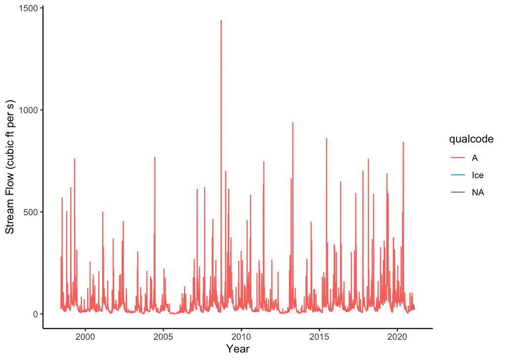

```r
jericho %>%
  ggplot(aes(dates, val, color = qualcode)) +
  geom_line() +
  labs(x = "Year", y = "Stream Flow (cubic ft per s)") +
  theme_classic()
```

The record runs from 1998 to present and almost all the data got the best quality flag. Only 10 missing values.

Does stream flow go to zero in winter? Let’s look at the last year of winter data (Dec - March 2019-2020).

```r
jericho_winter <- importDVs( "05551675" , code = "00060", stat = "00003", sdate = "2019-12-01",
  edate = as.Date("2020-03-31", format = "%Y-%m-%d"))
str(jericho_winter)
```

```
## 'data.frame':    122 obs. of  4 variables:
##  $ staid   : chr  "05551675" "05551675" "05551675" "05551675" ...
##  $ val     : num  102 99.2 89.9 86.4 79 83.2 70 66.5 66.1 60.4 ...
##  $ dates   : Date, format: "2019-12-01" "2019-12-02" ...
##  $ qualcode: chr  "A" "A" "A" "A" ...
##  - attr(*, "code")= chr "00060"
##  - attr(*, "stat")= chr "00003"
```

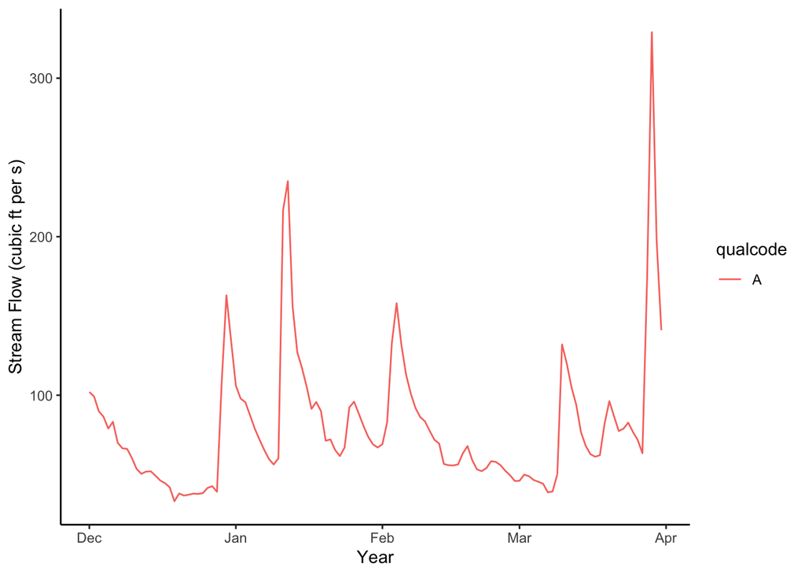

```r
jericho_winter %>%
  ggplot(aes(dates, val, color = qualcode)) +
  geom_line() +
  labs(x = "Year", y = "Stream Flow (cubic ft per s)") +
  theme_classic()
```

It appears some amount of flow continues during the winter.

Let’s check the **water temperature** values to see if it was every subzero (when you might expect no flow).

```r
jericho_winter_temps <- importDVs( "05551675" , code = "00010", stat = "00003", sdate = "2019-12-01",
  edate = as.Date("2020-03-31", format = "%Y-%m-%d"))
str(jericho_winter_temps)
```

```
## 'data.frame':    0 obs. of  0 variables
##  - attr(*, "url")= chr "https://waterservices.usgs.gov/nwis/dv/?format=waterml,2.0&site=05551675&parameterCd=00010&statCd=00003&startDt"| __truncated__
```

Looks like *water temperatures are not available* at Jericho. What about **dissolved O2**?

```r
jericho_winter_o2 <- importDVs( "05551675" , code = "00300", stat = "00003", sdate = "2019-12-01",
  edate = as.Date("2020-03-31", format = "%Y-%m-%d"))
str(jericho_winter_o2)
```

```
## 'data.frame':    0 obs. of  0 variables
##  - attr(*, "url")= chr "https://waterservices.usgs.gov/nwis/dv/?format=waterml,2.0&site=05551675&parameterCd=00300&statCd=00003&startDt"| __truncated__
```

Nope, it appears it’s only stream flow and gage height (stage, in feet). This was actually mentioned in the USGS station information.

1. **Blackberry Creek**
   - Station 2: “N Yorkville”

```r
yorkville <- importDVs( "05551700" , code = "00060", stat = "00003", sdate = "1851-01-01",
  edate = as.Date(Sys.Date(), format = "%Y-%m-%d"))
str(yorkville)
```

```
## 'data.frame':    22057 obs. of  4 variables:
##  $ staid   : chr  "05551700" "05551700" "05551700" "05551700" ...
##  $ val     : num  15 15 15 15 14 13 12 12 12 12 ...
##  $ dates   : Date, format: "1960-10-01" "1960-10-02" ...
##  $ qualcode: chr  "A" "A" "A" "A" ...
##  - attr(*, "code")= chr "00060"
##  - attr(*, "stat")= chr "00003"
```

Try plotting:

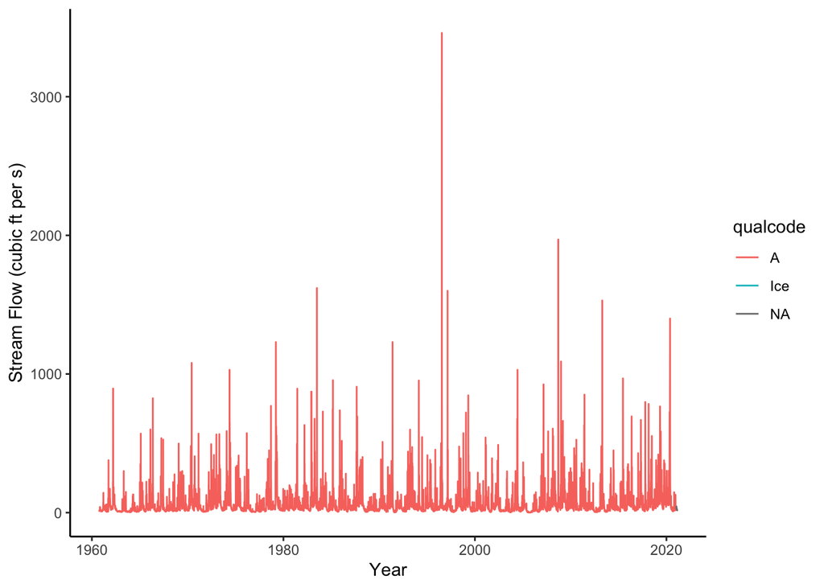

```r
yorkville %>%
  ggplot(aes(dates, val, color = qualcode)) +
  geom_line() +
  labs(x = "Year", y = "Stream Flow (cubic ft per s)") +
  theme_classic()
```

This record is much longer. 1960-present. It captures a large flood in the late 1990s. Almost all the data also got the highest quality flag. Only 6 missing values.

Let’s ask the same questions at Yorkville. Does stream flow go to zero in winter? Let’s look at the last year of winter data (Dec - March 2019-2020).

```r
yorkville_winter <- importDVs( "05551700" , code = "00060", stat = "00003", sdate = "2019-12-01",
  edate = as.Date("2020-03-31", format = "%Y-%m-%d"))
str(yorkville_winter)
```

```
## 'data.frame':    122 obs. of  4 variables:
##  $ staid   : chr  "05551700" "05551700" "05551700" "05551700" ...
##  $ val     : num  106 112 99.4 94.6 90.5 87.8 87.8 79.1 78.9 74.6 ...
##  $ dates   : Date, format: "2019-12-01" "2019-12-02" ...
##  $ qualcode: chr  "A" "A" "A" "A" ...
##  - attr(*, "code")= chr "00060"
##  - attr(*, "stat")= chr "00003"
```

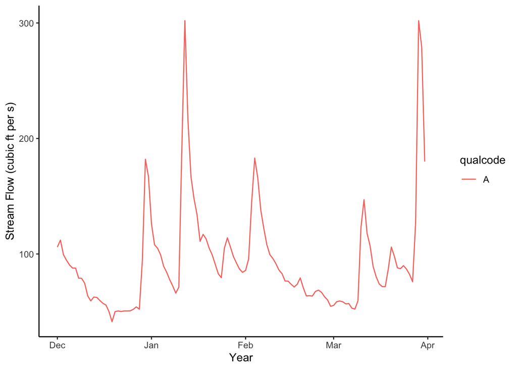

```r
yorkville_winter %>%
  ggplot(aes(dates, val, color = qualcode)) +
  geom_line() +
  labs(x = "Year", y = "Stream Flow (cubic ft per s)") +
  theme_classic()
```

It appears some amount of flow continues during the winter.

Let’s check the **water temperature** values to see if it was every subzero (when you might expect no flow).

```r
yorkville_winter_temps <- importDVs( "05551700" , code = "00010", stat = "00003", sdate = "2019-12-01",
  edate = as.Date("2020-03-31", format = "%Y-%m-%d"))
str(yorkville_winter_temps)
```

```
## 'data.frame':    0 obs. of  0 variables
##  - attr(*, "url")= chr "https://waterservices.usgs.gov/nwis/dv/?format=waterml,2.0&site=05551700&parameterCd=00010&statCd=00003&startDt"| __truncated__
```

Looks like *water temperatures are not available* at yorkville. What about **dissolved O2**?

```r
yorkville_winter_o2 <- importDVs( "05551700" , code = "00300", stat = "00003", sdate = "2019-12-01",
  edate = as.Date("2020-03-31", format = "%Y-%m-%d"))
str(yorkville_winter_o2)
```

```
## 'data.frame':    0 obs. of  0 variables
##  - attr(*, "url")= chr "https://waterservices.usgs.gov/nwis/dv/?format=waterml,2.0&site=05551700&parameterCd=00300&statCd=00003&startDt"| __truncated__
```

Nope, it also appears it’s only stream flow and gage height (stage, in feet).

```r
yorkville <- importDVs( "05551700" , code = "00060", stat = "00003", sdate = "2012-01-01",
  edate = as.Date("2015-12-31", format = "%Y-%m-%d"))
str(yorkville)
```

```
## 'data.frame':    1461 obs. of  4 variables:
##  $ staid   : chr  "05551700" "05551700" "05551700" "05551700" ...
##  $ val     : num  46.9 40.1 35.2 43.4 38.1 36.1 35.4 33.5 32.1 31.2 ...
##  $ dates   : Date, format: "2012-01-01" "2012-01-02" ...
##  $ qualcode: chr  "A" "A" "A" "A" ...
##  - attr(*, "code")= chr "00060"
##  - attr(*, "stat")= chr "00003"
```

Try plotting:

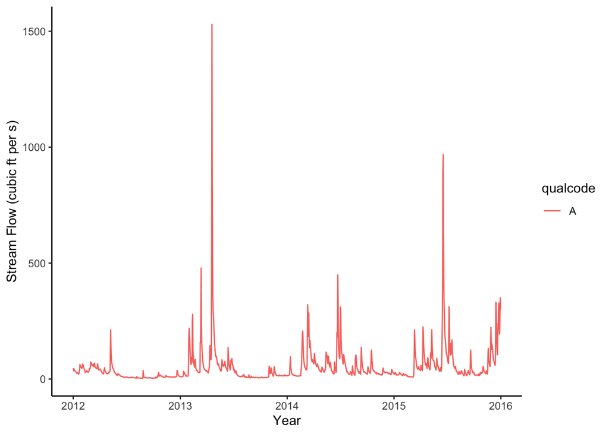

```r
yorkville %>%
  ggplot(aes(dates, val, color = qualcode)) +
  geom_line() +
  labs(x = "Year", y = "Stream Flow (cubic ft per s)") +
  theme_classic()
```